# I love VR but I always get motion sick! Using data science to predict cybersickness

Although Virtual Reality is considered by most people a great piece of technology, cybersickness symptoms are commonly experienced by users. But there is hope! Here, I will explore how data science can help predict cybersickness, which might be useful to employ cybersickness mitigation mechanisms.

1. Introduction
   1. High-Level overview
   2. Description of the input data
   3. Strategy for solving the problem
   4. Discussion of the expected solution
   5. Metrics
2. Exploratory Data Analysis
   1. Cybersickness Incidence
   2. Body Sway
   3. Body Sway and Cybersickness
      1. Females
      2. Males
   4. Could body sway be a predictor of cybersickness?
      1. Logistic Regression for the Inspection Task
      2. Logistic Regression for the Search Task
3. Using Machine Learning to Predict Cybersickness
   1. Time Series ML-Model
      1. Data preprocessing
      2. Modeling
      3. Hyperparameter Tuning
      4. Results
         1. Search Condition
         2. Inspection Condition
   2. Discrete data ML-Model
      1. Data preprocessing
      2. Modeling and Hyperparameter Tuning
      3. Results
         1. Search Condition
         2. Inspection Condition
      4. Results
   3. Comparing Models
4. Conclusion
5. Improvements
6. Acknowledgements
7. Extras - Contact Information

## Introduction

### High-Level overview

Currently, virtual reality (VR) is one of the hottest topics in technology. Cybersickness, however, represents one of the largest concerns of the industry. This condition is characterized by the same symptoms as motion sickness, including nausea, dizziness, disorientation, headaches, sweating, fatigue, and eye strain. The prevalence of these symptoms varies between 20 and 45%, with females having a higher incidence. While the etiology of that discomfort has been extensively studied, no consensus has been reached regarding its causes. My belief is that we fail to stabilize our bodies, resulting in cybersickness. The postural instability theory is based on this concept. You can see more about the theory and studies related to it in the article we recently published [HERE](https://www.frontiersin.org/articles/10.3389/frvir.2022.1001080/full).

Consequently, analyzing how people control their posture may provide some insight into who is more likely to experience motion sickness. The purpose of this article is to examine the relationship between cybersickness and posture. Specifically, we will examine machine-learning models trained with real-world data to determine if those models can be used to predict cybersickness. This is relevant because if we are able to predict people who will become sick in a virtual environment, then we may be able to develop specific strategies to mitigate cybersickness before the user becomes sick.

### Description of the input data

The dataset used in this analysis comes from three different experiments. In all of these experiments, before wearing the VR-headset and playing a driving game, participants stood on a force plate for one minute to perform two tasks. The first task required them to stare at the wall (inspection task) while the second required them to read a text on a paper on the wall (search task). As a result, we examined how the body moved in the tasks along the medio-lateral and anterior-posterior axes. After completing these tasks, participants played a virtual reality driving game. The participants played for 15 minutes or discontinued the game if they became ill. A complete description of the experiment design can be found [HERE](https://www.tandfonline.com/doi/abs/10.1080/10447318.2020.1726108). The dataset for the first experiment is available in a repository [HERE](https://conservancy.umn.edu/handle/11299/209152). The data for experiment 2 and 3 can be found [HERE](https://github.com/daniloarruda13/predicting-cybersickness-from-postural-data-with-machine-learning/tree/main/data).

[figure not shown]

Data preprocessing was quite a challenge for this project. You can access the scrip with the full preprocessing steps [HERE](https://github.com/daniloarruda13/predicting-cybersickness-from-postural-data-with-machine-learning/blob/main/pre_processing.py).

The challenge in this part comes from the fact that we are using three different datasets, from different experiments. Therefore, the data was arranged significantly different. The first step was to make a Pandas data frame using the force plate data (1x3000 for each participant in each condition) and add the cybersickness status and sex from a different spreadsheet using the unique participants IDs. Also, in the experiment 1, some participants were only passengers in the VR-driving game. Since this condition is considerably different from driving in VR, I removed those participants (n = 38), so all the participants in the dataset actually drove a car in virtual reality.

The compiled dataset contained 138 rows (for each condition) and 6005 columns. After the classification columns, the first 3000 columns represented the medio-lateral coordinates (X) and the last 3000 represented the anterior-posterior coordinates (Y). The initial analysis can be viewed below.

```python
#importing libraries
import warnings
import pandas as pd
import numpy as np
import re
import matplotlib.pyplot as plt
import seaborn as sns
import statsmodels.api as sm
import statsmodels.formula.api as smf
from scipy import stats
from scipy.spatial import ConvexHull

from sklearn.linear_model import LogisticRegression
from sklearn.ensemble import RandomForestClassifier, GradientBoostingClassifier
from sklearn.svm import SVC
from sklearn.tree import DecisionTreeClassifier
from sklearn.pipeline import Pipeline
from sklearn.preprocessing import StandardScaler
from sklearn.model_selection import train_test_split, GridSearchCV
from sklearn.metrics import accuracy_score, confusion_matrix

from pyts.classification import BOSSVS,TimeSeriesForest, SAXVSM, TSBF
from pyts.multivariate.classification import MultivariateClassifier
```

```python
#Importing datasets and concatenating them
def import_concat():
    inspection = pd.read_csv('data/inspection.csv')
    search = pd.read_csv('data/search.csv')

    #Concatening datasets
    df = pd.concat([inspection, search])
    return df

df = import_concat()
#Converting Experiment column to numeric
df['Experiment'] = df['Experiment'].apply(lambda x: 1 if x == 'exp_1' else (2 if x == 'exp_2' else 3))

#Converting Sex column to numeric, 1 = female, 2 = male
df['sex'] = df['sex'].apply(lambda x: 1 if x == 'F' else 2)

#Condition to numeric: 1 = inspection, 2 = search
df['Condition'] = df['Condition'].apply(lambda x: 1 if re.match('^inspection', x, re.IGNORECASE) else 2)
```

```python
def delete_outliers(df):
    """
    Deletes rows from a DataFrame that deviate from the mean of each column by 3 standard deviations.

    Parameters:
    - df: pandas DataFrame
        The input DataFrame containing the data to be processed.

    Returns:
    - cleaned_df: pandas DataFrame
        The cleaned DataFrame with outliers removed.

    """

    # Calculate z-scores for each column
    z_scores = stats.zscore(df)

    # Identify outliers
    threshold = 3
    outliers = (abs(z_scores) > threshold).any(axis=1)

    # Filter the DataFrame to get rows with outliers
    df_outliers = df[outliers]

    # Delete rows with outliers
    cleaned_df = df.drop(df_outliers.index)

    return cleaned_df

# Delete outliers
df = delete_outliers(df)
```

**Detrending the data**

A common procedure when analyzing postural data is to detrend the data. This ensures that the data are around 0, allowing comparison across participants. See below one example of the raw data and an example of the detrended data.

[figure not shown]

```python
# Define a function to detrend time series data
def detrend_time_series(df):
    """
    Detrends time series data by subtracting the mean of each row from the corresponding columns.

    Args:
        df (pandas.DataFrame): The input DataFrame containing time series data.

    Returns:
        pandas.DataFrame: A new DataFrame with detrended time series data.

    """
    df_copy = df.copy()
    # Subseting the columns
    ml_columns = df_copy.columns[5:3005]
    ap_columns = df_copy.columns[3005:]
    # Calculating the row mean
    ml_mean = df_copy[ml_columns].mean(axis=1)
    ap_mean = df_copy[ap_columns].mean(axis=1)

    df_copy[ml_columns] -= ml_mean.values.reshape(-1, 1)
    df_copy[ap_columns] -= ap_mean.values.reshape(-1, 1)

    return df_copy

#Detrending the datasets
det_df = detrend_time_series(df)
det_df.head()
```

|  | Experiment | part_id | sex | Condition | Sickness | 5 | 6 | 7 | 8 | 9 | ... | 5995 | 5996 | 5997 | 5998 | 5999 | 6000 | 6001 | 6002 | 6003 | 6004 |
| --- | --- | --- | --- | --- | --- | --- | --- | --- | --- | --- | --- | --- | --- | --- | --- | --- | --- | --- | --- | --- | --- |
| 0 | 1 | 0 | 1 | 1 | 1 | 0.774326 | 0.752326 | 0.738326 | 0.715326 | 0.686326 | ... | 0.173129 | 0.156129 | 0.138129 | 0.121129 | 0.119129 | 0.115129 | 0.115129 | 0.121129 | 0.112129 | 0.109129 |
| 1 | 1 | 1 | 2 | 1 | 0 | -0.062652 | -0.047652 | -0.037652 | -0.061652 | -0.069652 | ... | 0.533358 | 0.520358 | 0.527358 | 0.527358 | 0.523358 | 0.501358 | 0.501358 | 0.469358 | 0.426358 | 0.380358 |
| 2 | 1 | 2 | 1 | 1 | 1 | -0.251086 | -0.226086 | -0.217086 | -0.233086 | -0.225086 | ... | 0.259140 | 0.272140 | 0.279140 | 0.265140 | 0.249140 | 0.249140 | 0.246140 | 0.233140 | 0.233140 | 0.243140 |
| 3 | 1 | 3 | 2 | 1 | 1 | -0.251086 | -0.226086 | -0.217086 | -0.233086 | -0.225086 | ... | 0.259140 | 0.272140 | 0.279140 | 0.265140 | 0.249140 | 0.249140 | 0.246140 | 0.233140 | 0.233140 | 0.243140 |
| 4 | 1 | 4 | 1 | 1 | 0 | -0.023883 | -0.013883 | 0.007117 | 0.027117 | 0.037117 | ... | 1.031551 | 1.031551 | 1.015551 | 1.041551 | 1.061551 | 1.071551 | 1.079551 | 1.069551 | 1.081551 | 1.061551 |

5 rows × 6005 columns

### Strategy for solving the problem

There are multiple approaches to analyze this dataset. In order to tackle this problem, I decided to use two distinct strategies. Firstly, I identified the relevant features associated with cybersickness, such as sex and body sway area. Subsequently, I trained a machine learning model on a portion of the data and utilized another portion for making predictions. This approach allowed me to assess the model's performance using the accuracy metric.

For the second strategy, I decided to leverage the time-series data in its original form. Consequently, I selected a machine learning algorithm specifically designed to handle time series data, where each timestamp relies on preceding ones. I anticipated that this strategy would be more effective compared to using derived features of the time series, such as area or standard deviation. Altering the original data source or taking averages always carries the risk of losing valuable information. By employing a time series model, I could delve into all the intricacies and complexities inherent in the original data.

### Discussion of the expected solution

The analysis of this dataset was expected to present some challenges. Since the dataset was relatively small, the ability to train machine learning algorithms is limited. In addition, the differences in body-sway patterns are very subtle, and not all methods are capable of capturing them. If you consider it, we are attempting to predict who will become ill before exposure to virtual reality by simply asking people to stand on a force plate. It is a challenging and ambitious task.

I expected the model without time series information to perform worse than the other ones. Due to the small sample size, this model would have even fewer data points to work with, making accurate predictions more difficult. Also, considering the binomial nature of the response variable and the uneven distribution of response frequencies, such as a greater number of individuals not experiencing sickness, I expected both the discrete model and the time series model to encounter difficulties in predicting the participants who became sick.

### Metrics

I chose to utilize accuracy as the performance metric for both models. The primary consideration is that, ultimately, the most crucial aspect is whether the model correctly predicts the outcome or not. Accuracy provides a straightforward and intuitive measure of how well the model performs in terms of correctly classifying instances. However, this may present a problem. Since the response variable has a binomial uneven distribution, the model can predict only one response (for instance, 0) and still perform well. In order to mitigate these effects, I decided that instead of simply analyzing the score, I also used confusion matrices to analyze more in deep how the model made predictions.

## Exploratory Data Analysis

### Cybersickness Incidence

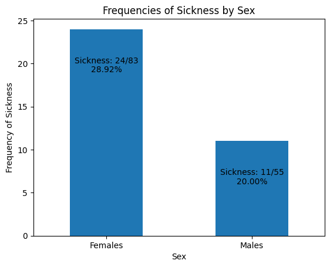

```python
def plot_sickness_frequencies(df):
    """
    Plots the frequencies of sickness by sex from the given DataFrame.

    Parameters:
    - det_inspection: pandas DataFrame
        The input DataFrame containing the det_inspection data.

    Returns:
    - None (displays the plot)
    """

    # Group the data by sex and calculate the frequencies of sickness
    sickness_frequencies = df.groupby('sex')['Sickness'].sum()
    n_counts = df['sex'].value_counts()

    # Create the bar plot
    ax = sickness_frequencies.plot(kind='bar')

    # Add labels and title
    plt.xlabel('Sex')
    plt.ylabel('Frequency of Sickness')
    plt.title('Frequencies of Sickness by Sex')

    # Rename the bar labels
    ax.set_xticklabels(['Females', 'Males'], rotation=0)

    # Add frequency and percentage labels to the bars
    for i, freq in enumerate(sickness_frequencies):
        count = n_counts[i+1]  # Access the count based on the index (1 for females, 2 for males)
        percentage = (freq / count) * 100
        plt.text(i, freq - 5, f'Sickness: {freq}/{count}\n{percentage:.2f}%', ha='center')

    # Show the plot
    plt.show()

#Frequencies in the inspection task
plot_sickness_frequencies(det_df[det_df['Condition']==1])
```

In total, there were 138 participants, 83 females and 55 males. Regarding cybersickness, 28.92% of the females got sick, and 20% of males. This might indicate that sex is a significant feature for cybersickness.

### Body Sway

The graphs below depict the mean of the body sway time series data across participants within that condition. A convex-hull method was used to calculate the area. The area of the average X and Y displacements of all participants is depicted in the figure title.

```python
def plot_time_series_grid(df1,df2,df3,df4,label1,label2,label3,label4):

    """
    Plot body sway time series grid and convex hulls for four different datasets.

    Parameters:
    df1, df2, df3, df4 (pandas.DataFrame): Dataframes containing the data to plot.
    The dataframes should have each column as a time point, representing the x and y coordinates
    of the data points.
    label1, label2, label3, label4 (str): Labels for the different datasets.

    Returns:
    None
    """

    # Subset 1: Label 1
    #Each column is a time point, the first half represents x and second half represents y
    x1 = df1.iloc[:, 5:3005].mean(axis=0)
    y1 = df1.iloc[:, 3005:].mean(axis=0)
    points1 = np.column_stack((x1, y1))
    hull1 = ConvexHull(points1,qhull_options='QJ')

    # Subset 2: Label 2
    x2 = df2.iloc[:, 5:3005].mean(axis=0)
    y2 = df2.iloc[:, 3005:].mean(axis=0)
    points2 = np.column_stack((x2, y2))
    hull2 = ConvexHull(points2,qhull_options='QJ')

    # Subset 3: Label 3
    x3 = df3.iloc[:, 5:3005].mean(axis=0)
    y3 = df3.iloc[:, 3005:].mean(axis=0)
    points3 = np.column_stack((x3, y3))
    hull3 = ConvexHull(points3,qhull_options='QJ')

    # Subset 4: Label 3
    x4 = df4.iloc[:, 5:3005].mean(axis=0)
    y4 = df4.iloc[:, 3005:].mean(axis=0)
    points4 = np.column_stack((x4, y4))
    hull4 = ConvexHull(points4,qhull_options='QJ')

    # Create the subplots
    fig, axs = plt.subplots(nrows=2, ncols=2, figsize=(10, 6))

    # Iterate over the subplots and add labels, titles, and axes
    for ax, points, hull in zip(axs.flatten(), [points1, points2, points3, points4], [hull1, hull2, hull3, hull4]):
        ax.plot(points[:, 0], points[:, 1], '-', color='blue', lw=0.5)
        ax.axhline(0, color='k', linestyle='-')
        ax.axvline(0, color='k', linestyle='-')

        if ax == axs[0, 0]:
            ax.set_title(f'{label1} / Area: {hull.area:.2f}')
            ax.set_ylabel('anterior-posterior (mm)')
            ax.set_xlabel('medio-lateral (mm)')
        elif ax == axs[0, 1]:
            ax.set_title(f'{label2} / Area: {hull.area:.2f}')
            ax.set_ylabel('anterior-posterior (mm)')
            ax.set_xlabel('medio-lateral (mm)')
        elif ax == axs[1, 0]:
            ax.set_title(f'{label3} / Area: {hull.area:.2f}')
            ax.set_ylabel('anterior-posterior (mm)')
            ax.set_xlabel('medio-lateral (mm)')
        elif ax == axs[1, 1]:
            ax.set_title(f'{label4} / Area: {hull.area:.2f}')
            ax.set_ylabel('anterior-posterior (mm)')
            ax.set_xlabel('medio-lateral (mm)')

        # Set the tick formatter for x and y axes
        ax.xaxis.set_major_formatter(plt.FormatStrFormatter('%.2f'))
        ax.yaxis.set_major_formatter(plt.FormatStrFormatter('%.2f'))

        # Plot the convex hull
        for simplex in hull.simplices:
            ax.plot(points[simplex, 0], points[simplex, 1], 'c')

        ax.plot(points[hull.vertices, 0], points[hull.vertices, 1], '--', mec='r', color='red', lw=1, markersize=10)
    # Adjust spacing
    plt.tight_layout()
    # Show the plot
    plt.show()
```

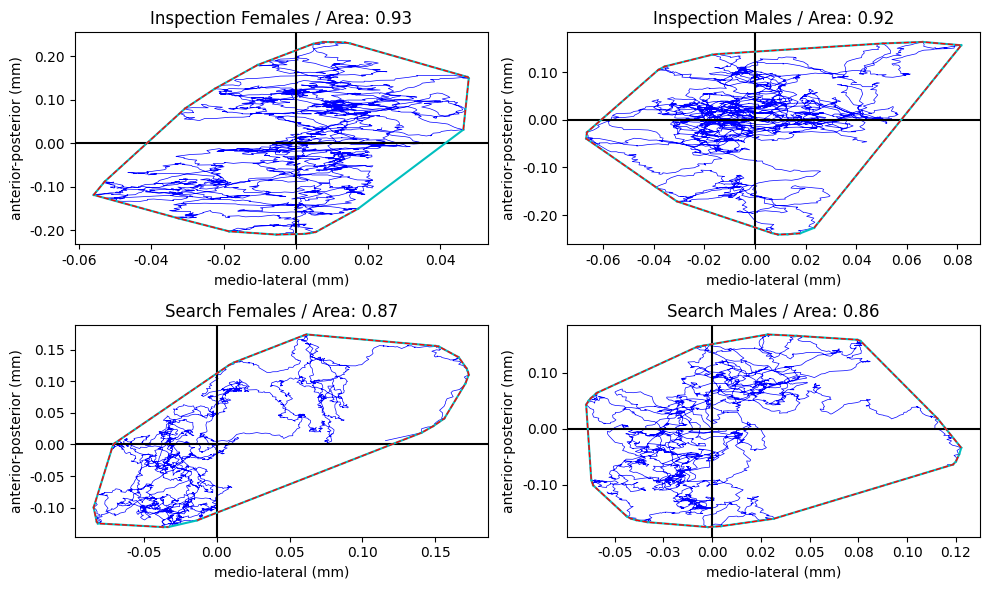

```python
#Ploting Conditions vs. Sex
plot_time_series_grid(det_df[(det_df['Condition'] == 1) & (det_df['sex'] == 1)],
                      det_df[(det_df['Condition'] == 1) & (det_df['sex'] == 2)],
                      det_df[(det_df['Condition'] == 2) & (det_df['sex'] == 1)],
                      det_df[(det_df['Condition'] == 2) & (det_df['sex'] == 2)],
                      'Inspection Females','Inspection Males','Search Females','Search Males')
```

When analyzing body sway patterns for the two tasks, we can see that the shapes and area were somewhat similar. It seems that for the search task, participants swayed more laterally in relation to the other conditions.

### Body Sway and Cybersickness

#### Females

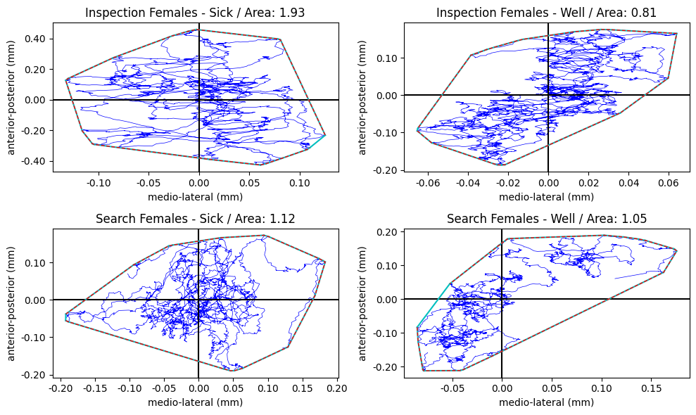

```python
# Plotting Sickness vs. Well for Females
plot_time_series_grid(
    det_df[(det_df['sex'] == 1) & (det_df['Sickness'] == 1)&(det_df['Condition'] == 1)],
    det_df[(det_df['sex'] == 1) & (det_df['Sickness'] == 0)&(det_df['Condition'] == 1)],
    det_df[(det_df['sex'] == 1) & (det_df['Sickness'] == 1)&(det_df['Condition'] == 2)],
    det_df[(det_df['sex'] == 1) & (det_df['Sickness'] == 0)&(det_df['Condition'] == 2)],
    'Inspection Females - Sick','Inspection Females - Well','Search Females - Sick',
    'Search Females - Well')
```

Analyzing the body sway patterns for females, we can see some differences between people who got sick and those who did not. For instance, in the inspection task, the area is much larger. Similarly, for the search task, but in much smaller magnitude. Please note that this task was performed before playing the VR game. So we did not know who would get sick. Still, those differences could be correlated to cybersickness.

#### Males

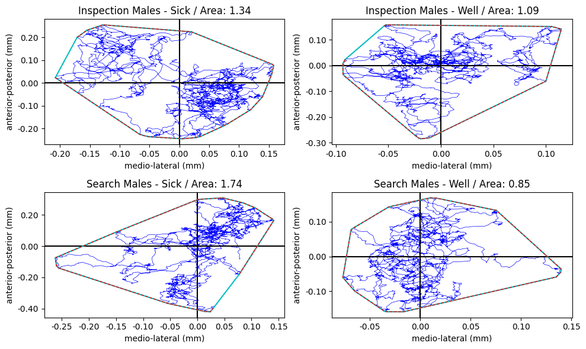

```python
# Plotting Sickness vs. Well for Males
plot_time_series_grid(
    det_df[(det_df['sex'] == 2) & (det_df['Sickness'] == 1)&(det_df['Condition'] == 1)],
    det_df[(det_df['sex'] == 2) & (det_df['Sickness'] == 0)&(det_df['Condition'] == 1)],
    det_df[(det_df['sex'] == 2) & (det_df['Sickness'] == 1)&(det_df['Condition'] == 2)],
    det_df[(det_df['sex'] == 2) & (det_df['Sickness'] == 0)&(det_df['Condition'] == 2)],
    'Inspection Males - Sick','Inspection Males - Well','Search Males - Sick',
    'Search Males - Well')
```

For males, we found a similar pattern, with those participants who got sick, showing a larger area. That might indicate that the body sway area could be an indicator of cybersickness.

### Could body sway be a predictor of cybersickness?

The answer to this question can be obtained by performing a binomial logistic regression that includes area and sex as predictors of cybersickness, and then performing statistical testing to determine whether the differences are significant. For each task, Inspection and Search, I constructed a simple additive model based on Sickness ~ Experiment + Sex + Area. Let's see the results below.

### Logistic Regression for the Inspection Task

```python
#Functions to calculate extra features
#calculate area
def calculate_hull_area(df):
    """
    Calculate the area of the convex hull for each row in the DataFrame.

    Args:
        df (DataFrame): Input DataFrame containing the coordinates.

    Returns:
        list: A list of areas of the convex hull for each row.

    """
    x = df.iloc[:, 5:3005]
    y = df.iloc[:, 3005:]
    col_area = []
    for i in range(len(x)):
        points = np.column_stack((x.iloc[i,:], y.iloc[i,:]))
        hull = ConvexHull(points,qhull_options='QJ')
        area = hull.area
        col_area.append(area)

    return col_area
```

```python
#Adding the area and running glm on the Inspection data
df_temp = det_df.iloc[:, :5]
df_temp['area'] = calculate_hull_area(det_df)
df_temp = df_temp[df['Condition'] == 1]

#Defining additive model with Sickness (binomial) as response variable
formula = 'Sickness ~  Experiment + sex + area'
model = smf.glm(formula=formula, data=df_temp, family=sm.families.Binomial(link=sm.families.links.logit()))
result = model.fit()
result.summary()
```

Generalized Linear Model Regression Results

| Dep. Variable: | Sickness | No. Observations: | 138 |
| --- | --- | --- | --- |
| Model: | GLM | Df Residuals: | 134 |
| Model Family: | Binomial | Df Model: | 3 |
| Link Function: | logit | Scale: | 1.0000 |
| Method: | IRLS | Log-Likelihood: | -69.431 |
| Date: | Thu, 15 Jun 2023 | Deviance: | 138.86 |
| Time: | 21:13:19 | Pearson chi2: | 138. |
| No. Iterations: | 5 | Pseudo R-squ. (CS): | 0.1187 |
| Covariance Type: | nonrobust |  |  |

|  | coef | std err | z | P>\|z\| | [0.025 | 0.975] |
| --- | --- | --- | --- | --- | --- | --- |
| Intercept | 1.4014 | 0.967 | 1.450 | 0.147 | -0.493 | 3.296 |
| Experiment | -1.1231 | 0.319 | -3.519 | 0.000 | -1.749 | -0.498 |
| sex | -0.6849 | 0.444 | -1.544 | 0.123 | -1.554 | 0.184 |
| area | 0.0888 | 0.071 | 1.243 | 0.214 | -0.051 | 0.229 |

For the inspection task, the results indicate that the variable "Experiment" has a significant effect on sickness, indicating that cybersickness incidence differed for experiments. The variables "Sex" and "Area" did not exhibit statistically significant effects on sickness. The Pseudo R-squared value of 0.1187 suggests that approximately 11.87% of the variation in sickness can be explained by the model.

### Logistic Regression for the Search Task

```python
#Adding the area and running glm on the search data
df_temp = det_df.iloc[:, :5]
df_temp['area'] = calculate_hull_area(det_df)
df_temp = df_temp[df['Condition'] == 2]


formula = 'Sickness ~  Experiment + sex + area'
model = smf.glm(formula=formula, data=df_temp, family=sm.families.Binomial(link=sm.families.links.logit()))
result = model.fit()
result.summary()
```

Generalized Linear Model Regression Results

| Dep. Variable: | Sickness | No. Observations: | 138 |
| --- | --- | --- | --- |
| Model: | GLM | Df Residuals: | 134 |
| Model Family: | Binomial | Df Model: | 3 |
| Link Function: | logit | Scale: | 1.0000 |
| Method: | IRLS | Log-Likelihood: | -67.825 |
| Date: | Thu, 15 Jun 2023 | Deviance: | 135.65 |
| Time: | 21:13:22 | Pearson chi2: | 138. |
| No. Iterations: | 5 | Pseudo R-squ. (CS): | 0.1389 |
| Covariance Type: | nonrobust |  |  |

|  | coef | std err | z | P>\|z\| | [0.025 | 0.975] |
| --- | --- | --- | --- | --- | --- | --- |
| Intercept | 0.9675 | 0.997 | 0.970 | 0.332 | -0.987 | 2.922 |
| Experiment | -1.2174 | 0.331 | -3.677 | 0.000 | -1.866 | -0.568 |
| sex | -0.6722 | 0.452 | -1.486 | 0.137 | -1.559 | 0.214 |
| area | 0.2057 | 0.095 | 2.156 | 0.031 | 0.019 | 0.393 |

For the search task, "Experiment" was again significant. But differently than the previous condition, "Area" exhibited a statistically significant effect on sickness, with a coefficient of 0.2057. This implies that an increase in the "Area" variable is associated with a higher likelihood of sickness. Finally, sex was not significant. The Pseudo R-squared value of 0.1389 suggests that approximately 13.89% of the variation in sickness can be explained by the model.

In summary, the overall results indicate that area was significant only for the search task. Additionally, the experiment was significant for both tasks, indicating that the experiments affected cybersickness differently. Furthermore, both models revealed that sex did not play a significant role in either task. Due to the fact that most studies have found a sex difference in cybersickness (and motion sickness), I expected the results to be replicated in this study. The approach we are using here certainly has some limitations, but I will discuss them in more detail later.

## Using Machine Learning to Predict Cybersickness

As part of our effort to predict cybersickness, we will build two machine-learning models (actually four). In the first model, I will use the time-series data obtained from the force plates (X, Y coordinates). An advantage of this method is that the model can capture the complexities of the data as they are, rather than using derivates such as area or standard deviation that may not adequately represent the pattern of the data. For the second model, I will use a more common model that uses area as the main feature to predict cybersickness and does not consider the time series data.

### Time Series ML-Model

To predict cybersickness, we will build a [BOSSVS](https://pyts.readthedocs.io/en/latest/generated/pyts.classification.BOSSVS.html) model from the package [pyts](https://pyts.readthedocs.io/en/latest/index.html). The approach of this model involves breaking down the time series data into smaller segments and analyzing the specific pattern in that segment using Symbolic Fourier Approximation (See more [here](https://www.researchgate.net/publication/321417648_Multivariate_Time_Series_Classification_with_WEASELMUSE)). Then, the transformed time series data, represented as fixed-length vectors through BOSSVS, is used to train a classification. This model learns the relationship between the BOSSVS-encoded vectors and the corresponding class labels, enabling predictions for new time series based on their encoded representations.

#### Data Preprocessing

In order to use pyts with multiple predictors, we have to put the data into a 3D array (samples, features, time stamps). The code below shows this process. Also, for convenience, I split the dataset into inspection and search, so we can fit the models separately.

```python
#Making function to convert the dataframes to 3D, which is the required format
# for the pyts package

def convert_to_3d(df):
    """
    Converts a dataframe into a 3D array by extracting specific columns and reshaping them.

    Parameters:
    - df: pandas DataFrame
        The input dataframe containing the data to be converted.

    Returns:
    - dataset_3d: numpy ndarray
        The converted 3D array with dimensions (n_samples, n_features, 1) where:
            - n_samples: number of samples in the input dataframe
            - n_features: number of features extracted from the dataframe (3000 in this case)

    """

    # Extract ml_pos and ap_pos from the dataframe
    ml_pos = df.iloc[:, 5:3005]
    ap_pos = df.iloc[:, 3005:]

    # Convert ml_pos and ap_pos to 3D arrays
    ml_pos_3d = np.expand_dims(ml_pos, axis=1)
    ap_pos_3d = np.expand_dims(ap_pos, axis=1)

    # Extract exp_id, sex, and sick from the dataframe
    exp_id = pd.DataFrame(df.iloc[:, 0])
    sex = pd.DataFrame(df.iloc[:, 2])
    sick = pd.DataFrame(df.iloc[:, 4])

    # Repeat the values to match the length of ml_pos and ap_pos
    exp_id_repeated = pd.concat([exp_id.T] * 3000).T.values
    sex_repeated = pd.concat([sex.T] * 3000).T.values
    sick_repeated = pd.concat([sick.T] * 3000).T.values


    # Expand dimensions of exp_id, sex, and sick arrays to match ml_pos_3d and ap_pos_3d
    exp_id_3d = np.expand_dims(exp_id_repeated, axis=1)
    sex_3d = np.expand_dims(sex_repeated, axis=1)
    sick_3d = np.expand_dims(sick_repeated, axis=1)


    # Concatenate the arrays along the second axis with swapped axes
    dataset_3d = np.concatenate((sick_3d, exp_id_3d, sex_3d, ml_pos_3d, ap_pos_3d), axis=1)

    return dataset_3d
```

```python
#Converting to 3D
det_df_3d_inspec = convert_to_3d(det_df[det_df['Condition'] == 1])
det_df_3d_search = convert_to_3d(det_df[det_df['Condition'] == 2])

print(f"Inspection shape: {det_df_3d_inspec.shape}\nSearch shape: {det_df_3d_search.shape}")
```

```
Inspection shape: (138, 5, 3000)
Search shape: (138, 5, 3000)
```

#### Modeling

The package pyts offers several functions that could be used to fit the models. Among the most suitable for this project, we could list the algorithms in the pyts classification package: SAXVSM, BOSSVS, LearningShapelets, TimeSeriesForest and TSBF. I could not run the LearningShapelets for some unknown reason, the fitting kept running indeterminately. After experimenting with different parameters, it was found that only the BOSSVS model was able to predict both 0s and 1s in the dataset. Although the other models had higher overall accuracy, they only predicted 0s and failed to correctly identify any of the 1s in the dataset. Due to the dataset containing more 0s than 1s, these models appeared to have a "higher" accuracy compared to the BOSSVS model, but what we are really interested is in the ability to predict cybersickness (1s in our dataset).

```python
#Ignore warnings
warnings.filterwarnings("ignore", category=FutureWarning, module="pyts")
warnings.filterwarnings("ignore", category=FutureWarning, module="sklearn")

############ WARNING This might take a few minutes to run
#Search data
df_temp = det_df_3d_search

# Data subset
X = df_temp[:, 1:, :]  # Input features
y = df_temp[:, 0, 0]  # Target variable

# Split the data into training and test sets
X_train, X_test, y_train, y_test = train_test_split(X, y, test_size=0.3, random_state=42)

#You can try different parameters for the models
#In the end, BOSSVS is the only one that is sensitive to predict both 0 and 1
models = {
    'BOSSVS': MultivariateClassifier(BOSSVS(window_size = 14)), #The default parameter (10) gives an error
    'SAXVSM': MultivariateClassifier(SAXVSM()),
    'TimeSeriesForest': MultivariateClassifier(TimeSeriesForest()),
    'TSBF': MultivariateClassifier(TSBF())
}

# Evaluate models using cross-validation
results = {}
for model_name, model in models.items():
    print(model_name)
    try:
        model = model.fit(X_train, y_train)
        acc = model.score(X_test, y_test)
        results[model_name] = acc
    except:
        pass

best_model = max(results, key=results.get)
best_accuracy = results[best_model]
#print(f"The best model is {best_model} with a mean accuracy of {best_accuracy:.2f}")
```

```
BOSSVS
SAXVSM
TimeSeriesForest
TSBF
```

```python
#Ignore warnings
warnings.filterwarnings("ignore", category=FutureWarning, module="pyts")
warnings.filterwarnings("ignore", category=FutureWarning, module="sklearn")

############ WARNING This might take a few minutes to run
#Inspection data
df_temp = det_df_3d_inspec

# Data subset
X = df_temp[:, 1:, :]  # Input features
y = df_temp[:, 0, 0]  # Target variable

# Split the data into training and test sets
X_train, X_test, y_train, y_test = train_test_split(X, y, test_size=0.3, random_state=42)

#You can try different parameters for the models
#In the end, BOSSVS is the only one that is sensitive to predict both 0 and 1
models = {
    'BOSSVS': MultivariateClassifier(BOSSVS(window_size = 14)), #The default parameter (10) gives an error
    'SAXVSM': MultivariateClassifier(SAXVSM()),
    'TimeSeriesForest': MultivariateClassifier(TimeSeriesForest()),
    'TSBF': MultivariateClassifier(TSBF())
}

# Evaluate models using cross-validation
results = {}
for model_name, model in models.items():
    print(model_name)
    try:
        model = model.fit(X_train, y_train)
        acc = model.score(X_test, y_test)
        results[model_name] = acc
    except:
        pass

best_model = max(results, key=results.get)
best_accuracy = results[best_model]
#print(f"The best model is {best_model} with a mean accuracy of {best_accuracy:.2f}")
```

```
BOSSVS
SAXVSM
TimeSeriesForest
TSBF
```

#### Hyperparameter Tuning

After some testing with the BOSSVS model, I found that the most significant parameters were the window size, the number of bins, and word size. [1]The window size determines the length of the sliding window used to extract subsequences from the time series data; [2]The number of bins controls the discretization of the data into a fixed number of intervals. It influences the granularity of the representation and the level of detail captured. A higher number of bins allows for a more fine-grained representation but may increase computational complexity and risk overfitting; [3]The word size refers to the length of the symbolic representations extracted from the subsequences. It determines the number of symbols that can be generated and affects the complexity and discriminative power of the resulting symbolic sequences. A larger word size can capture more detailed patterns but increases the dimensionality of the feature space.

```python
###### WARNING THIS WILL TAKE SEVERAL MINUTES TO RUN ########################
# Finding the best parameter for the Search Task
df_temp = det_df_3d_search
# data subset

X = df_temp[:, 1:, :]  # Input features
y = df_temp[:, 0, 0]  # Target variable

# Split the data into training and test sets
X_train, X_test, y_train, y_test = train_test_split(X, y, test_size=0.3, random_state=42)


w_s = [6, 8, 10]
wind_s = [336, 448, 560,1120,2240]
n_b = [6, 8, 10]

results = {}  # Container for results
#Gridsearch did not work here, so I had to do it manually
for w in w_s:
    for wind in wind_s:
        for n in n_b:
            model = BOSSVS(word_size=w, window_size = wind,n_bins=n)
            model = MultivariateClassifier(model)
            try:
                model.fit(X_train, y_train)
            except:
                print(f"ERROR: Could not fit Model (w={w}, wind={wind}, n={n})")
                continue
            score = model.score(X_test, y_test)
            label = f"Model (w={w}, wind={wind}, n={n})"
            results[label] = score

best_model_label = max(results, key=results.get)
best_model = results[best_model_label]

print("Best Model:", best_model_label)
print("Best Model Score:", best_model)
```

```
Best Model: Model (w=8, wind=448, n=6)
Best Model Score: 0.8333333333333334
```

```python
###### WARNING THIS WILL TAKE SEVERAL MINUTES TO RUN ########################
# Finding the best parameter for the Inspection Task
df_temp = det_df_3d_inspec
# data subset

X = df_temp[:, 1:, :]  # Input features
y = df_temp[:, 0, 0]  # Target variable

# Split the data into training and test sets
X_train, X_test, y_train, y_test = train_test_split(X, y, test_size=0.3, random_state=42)


w_s = [6, 8, 10, 12]
wind_s = [224, 336, 448, 560]
n_b = [6, 8, 10, 12]

results = {}  # Container for results
#Gridsearch did not work here, so I had to do it manually
for w in w_s:
    for wind in wind_s:
        for n in n_b:
            model = BOSSVS(word_size=w, window_size = wind,n_bins=n)
            model = MultivariateClassifier(model)
            try:
                model.fit(X_train, y_train)
            except:
                print(f"ERROR: Could not fit Model (w={w}, wind={wind}, n={n})")
                continue
            score = model.score(X_test, y_test)
            label = f"Model (w={w}, wind={wind}, n={n})"
            results[label] = score

best_model_label = max(results, key=results.get)
best_model = results[best_model_label]

print("Best Model:", best_model_label)
print("Best Model Score:", best_model)
```

```
Best Model: Model (w=8, wind=336, n=10)
Best Model Score: 0.7380952380952381
```

#### Results

##### Search Condition

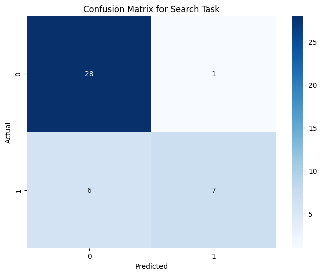

```python
#Running the best model
# Search
df_temp = det_df_3d_search
# data subset

X = df_temp[:, 1:, :]  # Input features
y = df_temp[:, 0, 0]  # Target variable

# Split the data into training and test sets
X_train, X_test, y_train, y_test = train_test_split(X, y, test_size=0.3, random_state=42)

model = BOSSVS(word_size=8, window_size = 448,n_bins=6)
model = MultivariateClassifier(model)
model.fit(X_train, y_train)

score = model.score(X_test, y_test)
label = f"Model (w={w}, wind={wind}, n={n})"
results[label] = score

# Obtain predictions for the test set
y_pred = model.predict(X_test)

# Create a confusion matrix
cm = confusion_matrix(y_test, y_pred)

# Plot the confusion matrix
plt.figure(figsize=(8, 6))
sns.heatmap(cm, annot=True, fmt='d', cmap='Blues')
plt.xlabel('Predicted')
plt.ylabel('Actual')
plt.title('Confusion Matrix for Search Task')
plt.show()
```

The model correctly classified sickness for 83% of the test samples. However, it is important to note that there were more 0s (non-sick) than 1s (sick). If we analyze the 1s, we can see that the model got 7/13 correct (~53%).

##### Inspection Condition

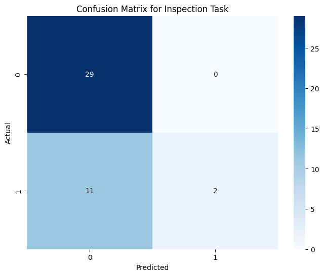

```python
#Run the best model
# Inspection
df_temp = det_df_3d_inspec
# data subset

X = df_temp[:, 1:, :]  # Input features
y = df_temp[:, 0, 0]  # Target variable

# Split the data into training and test sets
X_train, X_test, y_train, y_test = train_test_split(X, y, test_size=0.3, random_state=42)

model = BOSSVS(word_size=8, window_size = 336,n_bins=10)
model = MultivariateClassifier(model)
model.fit(X_train, y_train)
score = model.score(X_test, y_test)

# Obtain predictions for the test set
y_pred = model.predict(X_test)

# Create a confusion matrix
cm = confusion_matrix(y_test, y_pred)

# Plot the confusion matrix
plt.figure(figsize=(8, 6))
sns.heatmap(cm, annot=True, fmt='d', cmap='Blues')
plt.xlabel('Predicted')
plt.ylabel('Actual')
plt.title('Confusion Matrix for Inspection Task')
plt.show()
```

The model correctly classified sickness for 73% of the test samples. However, it is important to note that there were more 0s (non-sick) than 1s (sick). Additionally, this model was weak at predicting the 1s (sick participants), getting only 2/13 right (~15%).

### Discrete data ML-Model

For the following models, the time-series data will be removed from the dataset, leaving the following features: experiment, sex, and body sway area. To select the optimal model, again I selected the model with the best accuracy. The selection was done using the models: LogisticRegression, RandomForestClassifier, SVC, GradientBoostingClassifier, and DecisionTreeClassifier. These models are available in the scikit-learn (sklearn) library.

#### Data Preprocessing

For those models, we are subsetting the dataset to remove the time series data. In addition, we will add the area to the dataset.

```python
#Making new dataset without time series data and adding the area
det_df_discrete = det_df.iloc[:, 0:5]
det_df_discrete['area'] = calculate_hull_area(det_df)

det_df_discrete.head()
```

|  | Experiment | part_id | sex | Condition | Sickness | area |
| --- | --- | --- | --- | --- | --- | --- |
| 0 | 1 | 0 | 1 | 1 | 1 | 4.896835 |
| 1 | 1 | 1 | 2 | 1 | 0 | 3.869067 |
| 2 | 1 | 2 | 1 | 1 | 1 | 3.484885 |
| 3 | 1 | 3 | 2 | 1 | 1 | 3.484885 |
| 4 | 1 | 4 | 1 | 1 | 0 | 4.259879 |

#### Modeling and Hyperparameter Tuning

##### Search Condition

For the search data, the best model was a Logistic Regression, using the LogisticRegression function from the package sklearn (learn more [here](https://scikit-learn.org/stable/modules/generated/sklearn.linear_model.LogisticRegression.html#sklearn.linear_model.LogisticRegression)). It utilizes the logistic function (sigmoid) to map real-valued numbers into probabilities between 0 and 1. After attributing weights, a decision boundary is established, the trained model can then predict class probabilities for new instances, with thresholds determining the final class labels.

```python
#Finding the best model for search task
df_temp = det_df_discrete[det_df_discrete['Condition']==2]
# data subset
X = df_temp.drop(columns=['part_id','Sickness']) # Input features
y = df_temp['Sickness']  # Target variable

# Split the data into training and test sets
X_train, X_test, y_train, y_test = train_test_split(X, y, test_size=0.3, random_state=42)

models = [
    (LogisticRegression(), {'model__C': [0.1, 1, 10], 'model__penalty': ['l1', 'l2'], 'model__solver': ['liblinear', 'saga']}),
    (RandomForestClassifier(), {'model__n_estimators': [100, 200, 300], 'model__max_features': ['sqrt', 'log2']}),
    (SVC(), {'model__C': [0.1, 1, 10], 'model__gamma': [0.1, 0.01], 'model__degree': [3, 6, 9], 'model__kernel': ['linear', 'rbf']}),
    (GradientBoostingClassifier(), {'model__learning_rate': [0.1, 0.01, 0.001], 'model__n_estimators': [100, 200, 300]}),
    (DecisionTreeClassifier(), {'model__max_depth': [None, 5, 10, 15], 'model__min_samples_split': [2, 5, 10]})
]


# Creating empty variables to store the best model and its performance
best_model_search = None
best_model_name = ""
best_accuracy = -float('inf')


# Iterate over models and their parameter grids
for model, param_grid in models:
    # Create a pipeline with scaler and model
    pipeline = Pipeline([('scaler', StandardScaler()), ('model', model)])

    # Perform grid search with cross-validation
    grid_search = GridSearchCV(pipeline, param_grid, cv=5)
    grid_search.fit(X_train, y_train)

    # Use the current model to predict the test set targets
    y_test_preds = grid_search.predict(X_test)
    y_test_preds = (y_test_preds >= 0.5).astype(int)  # Convert probabilities to binary predictions

    # Calculate the R-squared score between the true and predicted test set targets
    accuracy = accuracy_score(y_test, y_test_preds)
    print(accuracy)
    # If the current model has a higher R-squared score than the previous best model, update the best model and R-squared score
    if accuracy > best_accuracy:
        best_accuracy = accuracy
        best_model_search = grid_search.best_estimator_
        best_model_name = type(best_model_search.named_steps['model']).__name__
        best_params = grid_search.best_params_


    for param, value in best_model_search.get_params().items():
        if param.startswith('model__'):
            param_name = param.replace('model__', '')

print(f"Best model: {best_model_name}, Accuracy: {best_accuracy}\n Parameters: {best_params}")
```

```
0.6904761904761905
0.5714285714285714
0.6904761904761905
0.6904761904761905
0.6428571428571429
Best model: LogisticRegression, Accuracy: 0.6904761904761905
 Parameters: {'model__C': 0.1, 'model__penalty': 'l1', 'model__solver': 'liblinear'}
```

##### Inspection Condition

```python
#Finding the best model for Inspection task
df_temp = det_df_discrete[det_df_discrete['Condition']==1]
# data subset
X = df_temp.drop(columns=['part_id','Sickness']) # Input features
y = df_temp['Sickness']  # Target variable

# Split the data into training and test sets
X_train, X_test, y_train, y_test = train_test_split(X, y, test_size=0.3, random_state=42)

models = [
(LogisticRegression(), {'model__C': [0.1, 1, 10], 'model__penalty': ['l1', 'l2'], 'model__solver': ['liblinear', 'saga']}),
(RandomForestClassifier(), {'model__n_estimators': [100, 200, 300], 'model__max_features': ['sqrt', 'log2']}),
(SVC(), {'model__C': [0.1, 1, 10], 'model__gamma': [0.1, 0.01], 'model__degree': [3, 6, 9], 'model__kernel': ['linear', 'rbf',]}),
(GradientBoostingClassifier(), {'model__learning_rate': [0.1, 0.01, 0.001], 'model__n_estimators': [100, 200, 300]}),
(DecisionTreeClassifier(), {'model__max_depth': [None, 5, 10, 15], 'model__min_samples_split': [2, 5, 10]})
]

# Creating empty variables to store the best model and its performance
best_model_inspection = None
best_model_name = ""
best_accuracy = -float('inf')


# Iterate over models and their parameter grids
for model, param_grid in models:
    # Create a pipeline with scaler and model
    pipeline = Pipeline([('scaler', StandardScaler()), ('model', model)])

    # Perform grid search with cross-validation
    grid_search = GridSearchCV(pipeline, param_grid, cv=5)
    grid_search.fit(X_train, y_train)

    # Use the current model to predict the test set targets
    y_test_preds = grid_search.predict(X_test)
    y_test_preds = (y_test_preds >= 0.5).astype(int)  # Convert probabilities to binary predictions

    # Calculate the R-squared score between the true and predicted test set targets
    accuracy = accuracy_score(y_test, y_test_preds)
    print(accuracy)
    # If the current model has a higher R-squared score than the previous best model, update the best model and R-squared score
    if accuracy > best_accuracy:
        best_accuracy = accuracy
        best_model_inspection = grid_search.best_estimator_
        best_model_name = type(best_model_inspection.named_steps['model']).__name__
        best_params = grid_search.best_params_


    for param, value in best_model_inspection.get_params().items():
        if param.startswith('model__'):
            param_name = param.replace('model__', '')

print(f"Best model: {best_model_name}, Accuracy: {best_accuracy}\n Parameters: {best_model_inspection.get_params()}")
```

[output not shown]

#### Results

##### Search Task

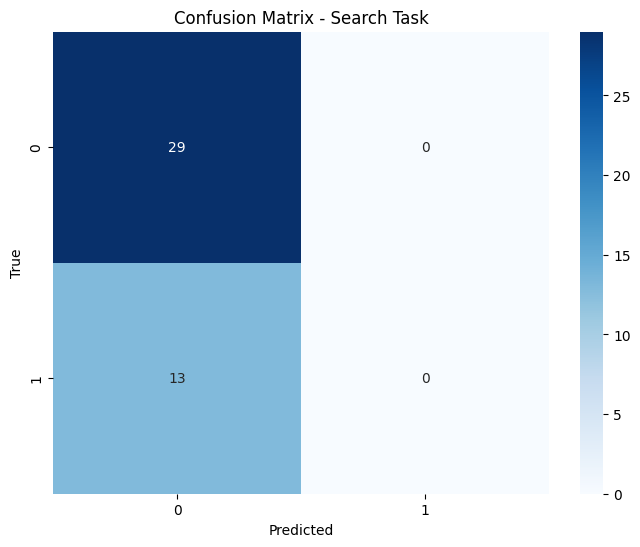

```python
# Fit the pipeline on the training data
best_model_search.fit(X_train, y_train)

# Use the best model to predict the test set targets
y_test_preds = best_model_search.predict(X_test)
y_test_preds = (y_test_preds >= 0.5).astype(int)  # Convert probabilities to binary predictions

# Calculate the confusion matrix
confusion = confusion_matrix(y_test, y_test_preds)

# Create a heatmap of the confusion matrix
plt.figure(figsize=(8, 6))
sns.heatmap(confusion, annot=True, fmt='d', cmap='Blues')
plt.xlabel('Predicted')
plt.ylabel('True')
plt.title('Confusion Matrix - Search Task')

plt.show()
```

##### Inspection Task

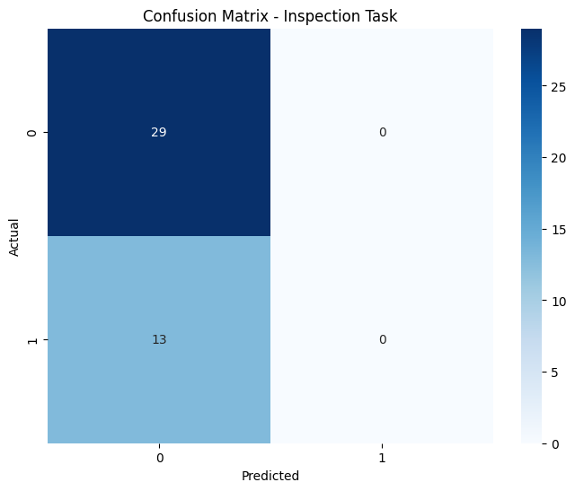

```python
# Fit the pipeline on the training data
best_model_inspection.fit(X_train, y_train)

# Use the best model to predict the test set targets
y_test_preds = best_model_inspection.predict(X_test)
y_test_preds = (y_test_preds >= 0.5).astype(int)  # Convert probabilities to binary predictions

# Calculate the confusion matrix
confusion = confusion_matrix(y_test, y_test_preds)

# Create a heatmap of the confusion matrix
plt.figure(figsize=(8, 6))
sns.heatmap(confusion, annot=True, fmt='d', cmap='Blues')
plt.xlabel('Predicted')
plt.ylabel('Actual')
plt.title('Confusion Matrix - Inspection Task')

plt.show()
```

This model exhibited lower efficiency compared to the previous ones, achieving an accuracy of 69%. However, upon examining the confusion matrix, it becomes evident that the model struggled in identifying individuals who were sick. Remarkably, it appears that the inspection task lacked the necessary sensitivity to promote variations in body sway that may contribute to cybersickness.

### Comparing Models

In comparing the models used in this study, it can be seen that using time series data is fundamental to predicting cybersickness. A second interesting finding was that the results generated by the two tasks were very different. Cybersickness appears not to be related to the inspection task. The results indicate that more research should be conducted to determine the most optimal task for capturing the body sway patterns, which will result in more accurate predictions. Finally, in future studies, combining different algorithms could be explored to further improve the accuracy of the models.

## Conclusion

In conclusion, our analysis of the different models used in this study reveals that the time series models outperformed the discrete models in terms of predictive accuracy. However, it is important to consider the limitations of the dataset, particularly its size and the variation in data sources due to different experiments.

The superiority of the time series models highlights the importance of capturing temporal patterns and dependencies in the data for accurate predictions. Leveraging the sequential nature of the time series data provided a more comprehensive understanding of the underlying patterns, resulting in improved model performance.

In light of the constraints posed by our analyses and datasets, we have successfully demonstrated the feasibility of utilizing motion data to predict cybersickness prior to individuals entering VR. This finding holds immense significance as it enables VR developers to design a preliminary application that identifies individuals susceptible to cybersickness before engaging in VR experiences. This proactive approach empowers developers to implement tailored strategies for cybersickness mitigation, thereby enhancing the overall user experience and ensuring user comfort and safety during VR interactions.

## Improvements

This is a highly exploratory investigation and certainly there is much room for improvement. Certainly, including a larger dataset might significantly increase the accuracy of the models. Predicting cybersickness is an ongoing process, and over time more data will be available to improve the models. Another improvement relates to how the models were designed. Potentially, trying out more models, and experimenting different parameters could help to further improve the results. In addition, using a combination of models or algorithms could also be explored. Finally, in this analysis we divided the models according to the tasks. However, maybe including the two tasks in the same model could feed the model with relevant information and improve its performance.

## Acknowledgements

The data used in this project is the property of Affordance Perception-Action Laboratory. It is not to be published, shared, or distributed without explicit authorization. This data is provided solely for the purpose of transparency when generating the models. If you are interested in using this data, please contact me to request permission and obtain the necessary authorization. Any unauthorized use or distribution of this data is strictly prohibited and may result in legal action.

## Extras - Contact Information

This blog post is an initial effort in developing predictive models for cybersickness. If you want to collaborate and help, please reach out to my email at daniloarruda13@gmail.com. Also, the complete analysis and scripts are publicly available in a GitHub repository [here](https://github.com/daniloarruda13/predicting-cybersickness-from-postural-data-with-machine-learning)